# TODAS AS ETAPAS DE UM PROJETO DE CIÊNCIA DE DADOS

luisotavio.pro

03/03/2021

(esse material complementar foi 100% produzido usando a linguagem R)

## Conteúdo exclusivo para o grupo de Whatsapp - AULA 02 - TODAS AS ETAPAS DE UM PROJETO DE CIÊNCIA DE DADOS

[**Assistir a live TODAS AS ETAPAS DE UM PROJETO DE CIÊNCIA DE DADOS**](http://lp.luisotavio.pro/aulas?blog=x2vpkkf6&video=mg75bur1)

## OBJETIVO DA SEMANA DO CIENTISTA DE DADOS:

- **te mostrar como você pode se tornar um Cientista de Dados em 5 meses e estar pronto para conseguir o seu primeiro emprego na área.**
  - Mesmo que você não saiba programar
  - Mesmo que não saiba inglês
  - Mesmo que não saiba estatística

Esse número (5 meses) não é aleatório. Ele foi calculado seguindo o método que começamos a falar na AULA 01.

## PRA QUEM É O MÉTODO QUE CRIEI?

- Para quem nunca programou na vida e deseja começar

[figure not shown]

- Ou pra quem não programava e achava que seria difícil

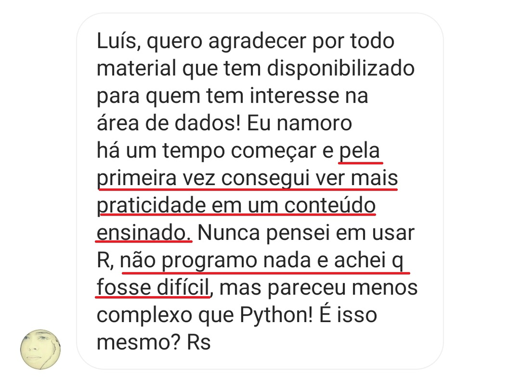

- Pra quem é de uma área distante da Estatística ou Computação. Já recebi vários trabalhos excelentes a partir do conteúdo disponibilizado no Blog, enviados por seguidores sem nenhuma relação com a Ciência de Dados. Como o Francisco (formado em Letras) ou o Fellipe Porto (Cientista Social).

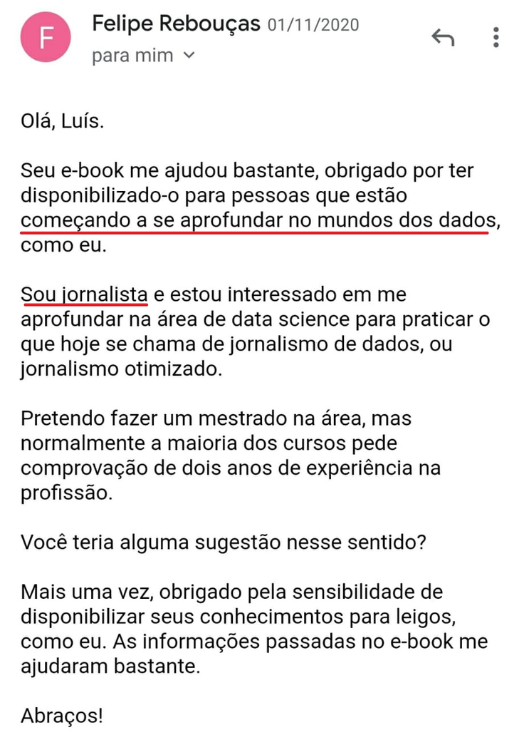

- Pra quem já perdeu tempo ou se estressou tentando aprender com métodos que não funcionam

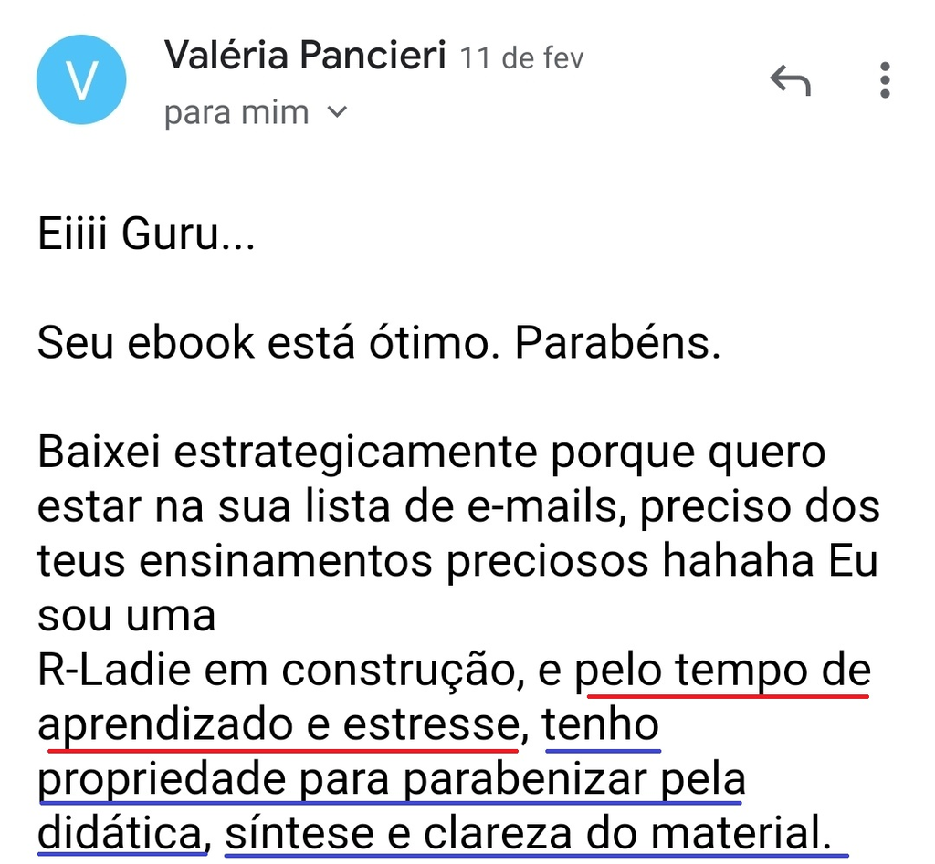

- Pra quem quer evoluir profissionalmente, conhecer novas ferramentas e impressionar o chefe

[figure not shown]

- Pra quem já tem conhecimento de programação ou Estatística, mas estava há muitos anos sem praticar, como o Eduardo, por exemplo

[figure not shown]

## E pra quem o método não serve?

- Não é para pessoas que acham que vão estudar poucas horas e conseguir o emprego dos sonhos
- Não é para quem deseja continuar fazendo o mesmo serviço o resto da carreira, sem se atualizar e aplicar as técnicas que estão revolucionando o mercado.
- Não é para quem deseja aprender somente a teoria, sem nenhuma aplicação prática.

# ETAPAS DE QUALQUER PROJETO DE CIÊNCIA DE DADOS

1º PASSO: DEFINIR QUAL O PROBLEMA PRECISA SER RESOLVIDO.

#### 5 ETAPAS:

**Caçador** – Obtenção dos dados

**Faxineiro** - Limpeza dos Dados

**Detetive** – Explorar/Visualizar os dados – encontrar padrões e tendências

**Mago** – Criar modelos preditivos

**Rei** – Interpretar os dados e tomar decisões

### Caçador – Obtenção dos dados

Principais fontes de dados:

- Planilha do Excel
- Arquivo CSV
- Buscar os dados em uma API
- Capturar os dados em site da internet via Webscraping

### Faxineiro - Limpeza dos Dados

“Garbage in, garbage out” -> Se você usar dados “sujos”, o resultado do projeto será ruim.

Examine os dados : entenda cada variável com a qual você está trabalhando, identifique erros, valores ausentes e registros corrompidos.

### Detetive – Explorar/Visualizar os dados – encontrar padrões e tendências

Encontre padrões em seus dados por meio de visualizações/gráficos

Nessa etapa também podemos fazer testes estatísticos e calcular estatísticas descritivas.

Exemplo com o conjunto de dados *iris*, que possui medidas de comprimento e largura de flores e suas espécies:

Cabeçalho dos dados

```r
data(iris)
head(iris)
```

```
##   Sepal.Length Sepal.Width Petal.Length Petal.Width Species
## 1          5.1         3.5          1.4         0.2  setosa
## 2          4.9         3.0          1.4         0.2  setosa
## 3          4.7         3.2          1.3         0.2  setosa
## 4          4.6         3.1          1.5         0.2  setosa
## 5          5.0         3.6          1.4         0.2  setosa
## 6          5.4         3.9          1.7         0.4  setosa
```

Nomes das variáveis

```r
names(iris)
```

```
## [1] "Sepal.Length" "Sepal.Width"  "Petal.Length" "Petal.Width"  "Species"
```

Frequência dos exemplares em relação a variável espécie

```r
table(iris$Species)
```

```
##
##     setosa versicolor  virginica
##         50         50         50
```

Resumo dos dados, variável por variável

```r
summary(iris)
```

```
##   Sepal.Length    Sepal.Width     Petal.Length    Petal.Width
##  Min.   :4.300   Min.   :2.000   Min.   :1.000   Min.   :0.100
##  1st Qu.:5.100   1st Qu.:2.800   1st Qu.:1.600   1st Qu.:0.300
##  Median :5.800   Median :3.000   Median :4.350   Median :1.300
##  Mean   :5.843   Mean   :3.057   Mean   :3.758   Mean   :1.199
##  3rd Qu.:6.400   3rd Qu.:3.300   3rd Qu.:5.100   3rd Qu.:1.800
##  Max.   :7.900   Max.   :4.400   Max.   :6.900   Max.   :2.500
##        Species
##  setosa    :50
##  versicolor:50
##  virginica :50
##
##
##
```

Desvio padrão do comprimento da sépala

```r
sd(iris$Sepal.Length)
```

```
## [1] 0.8280661
```

Cruzamento entre variáveis

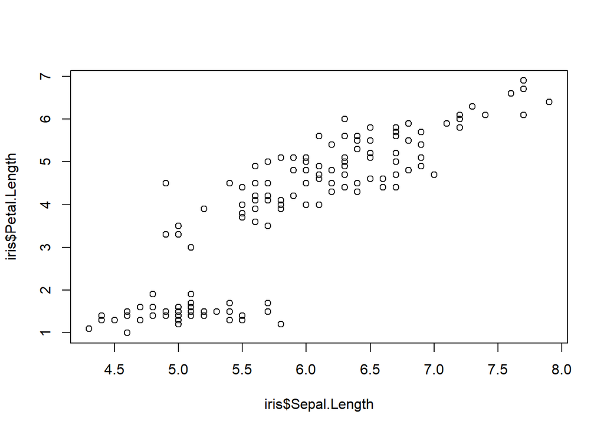

```r
plot(iris$Sepal.Length,iris$Petal.Length)
```

Histograma

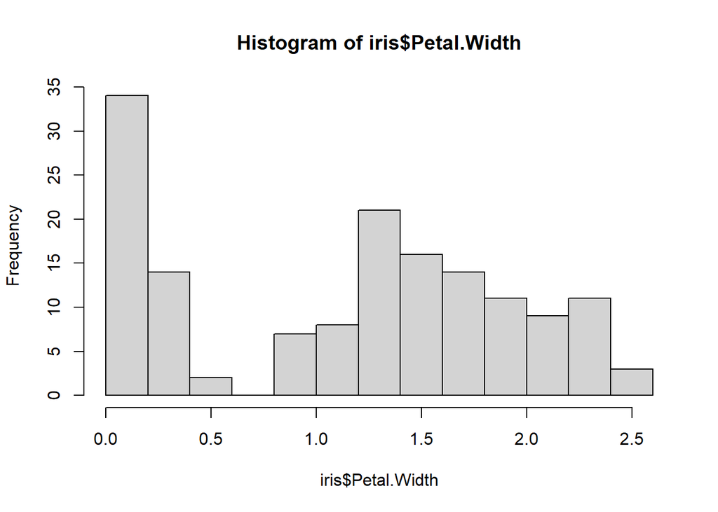

```r
hist(iris$Petal.Width)
```

Boxplot

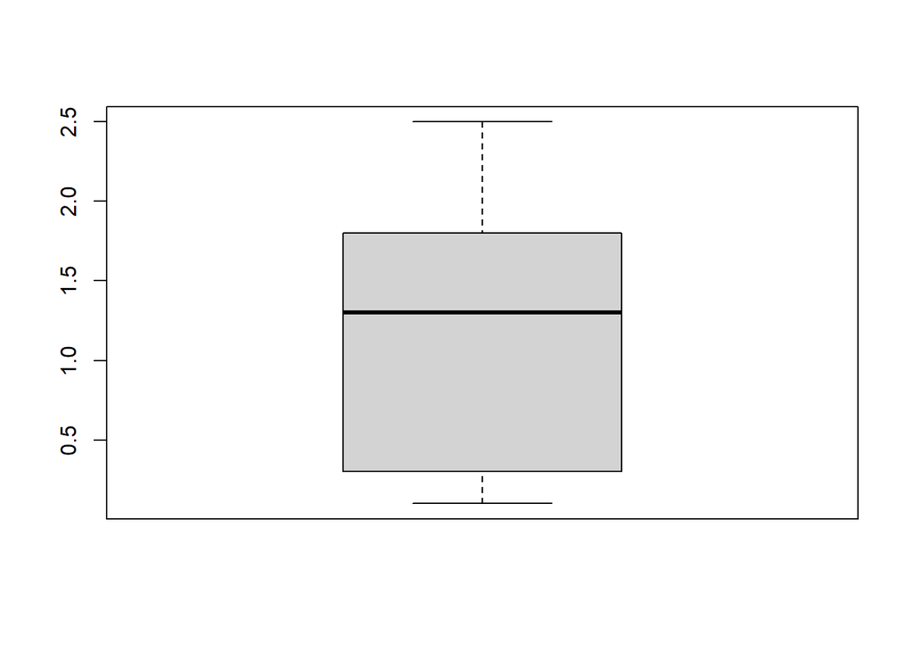

```r
boxplot(iris$Petal.Width)
```

- Crie perguntas e as responda

Existe diferença entre os comprimentos médios das sépalas de acordo com a espécie da flor?

```r
library(dplyr)
iris %>%
  group_by(Species)%>%
  summarise(comp_sepala = mean(Sepal.Length),
            desvio_padrao = sd(Sepal.Length))
```

```
## # A tibble: 3 x 3
##   Species    comp_sepala desvio_padrao
##   <fct>            <dbl>         <dbl>
## 1 setosa            5.01         0.352
## 2 versicolor        5.94         0.516
## 3 virginica         6.59         0.636
```

### Mago – modelar os dados - Super poder de PREVISÃO

**Machine Learning**

Métodos supervisionados

```
  - Regressão (Ex: prever a nota de um jogador de futebol em uma partida)

  - Classificação (Ex:classificar clientes de um banco em bons ou maus pagadores)
```

Não supervisionados

```
  - Agrupamento (Ex: segmentação de clientes)
```

### Rei – Interpretar os dados e tomar decisões

- Passar com clareza os resultados do seu trabalho, mesmo que seu chefe ou cliente não entenda nada de Ciência de Dados.
- Colocar os resultados do seu modelo para funcionarem na prática
- Exemplos de visualização de Dados que auxiliam na tomada de decisões

https://luisotavio.info/shiny/facebook-ads (melhor visualização pelo computador)

https://luisotavio.info/shiny/corona (melhor visualização pelo computador)

## PRÓXIMO PASSO - AULA 03 - **HOJE** - QUINTA-FEIRA, DIA 04/03, ÀS 20H (HORÁRIO BRASÍLIA)

### AULA 03 - O PASSO A PASSO PRA QUEM QUISER SE TORNAR UM CIENTISTA DE DADOS.

[**Clique aqui e defina o lembrete no Youtube**](https://youtu.be/3HwP0zRGaqQ)

Obrigado por acompanhar. Bora transformar a sua carreira.

Vamo que vamo!

Luís Otávio